# Risk Factor Analysis

## Outcome Variable

**Outcome Variable:** whz

## Predictor Variables

**Intervention Variable:** brthmon

**Adjustment Set:**

unadjusted

## Stratifying Variables

The analysis was stratified on these variable(s):

- agecat

## Data Summary

| agecat | brthmon | n_cell | n | outcome_variable |
| --- | --- | --- | --- | --- |
| Birth | 1 | 4149 | 52937 | whz |
| Birth | 2 | 3894 | 52937 | whz |
| Birth | 3 | 4487 | 52937 | whz |
| Birth | 4 | 3878 | 52937 | whz |
| Birth | 5 | 3481 | 52937 | whz |
| Birth | 6 | 3827 | 52937 | whz |
| Birth | 7 | 4404 | 52937 | whz |
| Birth | 8 | 4799 | 52937 | whz |
| Birth | 9 | 5001 | 52937 | whz |
| Birth | 10 | 4943 | 52937 | whz |
| Birth | 11 | 4897 | 52937 | whz |
| Birth | 12 | 5177 | 52937 | whz |
| 6 months | 1 | 4152 | 58096 | whz |
| 6 months | 2 | 4154 | 58096 | whz |
| 6 months | 3 | 5092 | 58096 | whz |
| 6 months | 4 | 4428 | 58096 | whz |
| 6 months | 5 | 4257 | 58096 | whz |
| 6 months | 6 | 4332 | 58096 | whz |
| 6 months | 7 | 5041 | 58096 | whz |
| 6 months | 8 | 5565 | 58096 | whz |
| 6 months | 9 | 5350 | 58096 | whz |
| 6 months | 10 | 5293 | 58096 | whz |
| 6 months | 11 | 5234 | 58096 | whz |
| 6 months | 12 | 5198 | 58096 | whz |
| 24 months | 1 | 1512 | 24375 | whz |
| 24 months | 2 | 2097 | 24375 | whz |
| 24 months | 3 | 2417 | 24375 | whz |
| 24 months | 4 | 1939 | 24375 | whz |
| 24 months | 5 | 1702 | 24375 | whz |
| 24 months | 6 | 1829 | 24375 | whz |
| 24 months | 7 | 2235 | 24375 | whz |
| 24 months | 8 | 2209 | 24375 | whz |
| 24 months | 9 | 2083 | 24375 | whz |
| 24 months | 10 | 2016 | 24375 | whz |
| 24 months | 11 | 2042 | 24375 | whz |
| 24 months | 12 | 2294 | 24375 | whz |

The following strata were considered:

- agecat: 24 months
- agecat: 6 months
- agecat: Birth

## Methods Detail

We’re interested in the causal parameters $E[Y_a]$ for all values of $a \in \mathcal{A}$. These parameters represent the mean outcome if, possibly contrary to fact, we intervened to set all units to have $A=a$. Under the randomization and positivity assumptions, these are identified by the statistical parameters $\psi_a=E_W[E_{Y|A,W}(Y|A=a,W)]$. In addition, we’re interested in the mean of $Y$, $E[Y]$ under no intervention (the observed mean). We will estimate these parameters by using SuperLearner to fit the relevant likelihood factors – $E_{Y|A,W}(Y|A=a,W)$ and $p(A=a|W)$, and then updating our likelihood fit using a joint TMLE.

For unadjusted analyses ($W=\{\}$), initial likelihoods were estimated using Lrnr_glm to estimate the simple $E(Y|A)$ and Lrnr_mean to estimate $p(A)$. For adjusted analyses, a small library containing Lrnr_glmnet, Lrnr_xgboost, and Lrnr_mean was used.

Having estimated these parameters, we will then use the delta method to estimate relative risks and attributable risks relative to a prespecified baseline level of $A$.

# Results Detail

## Results Plots

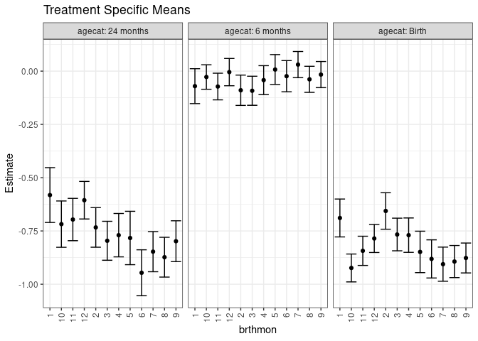

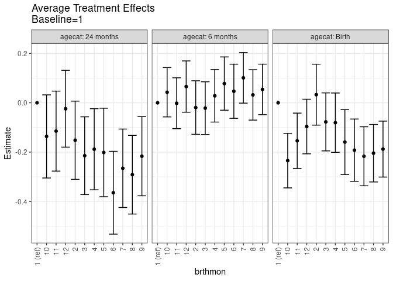

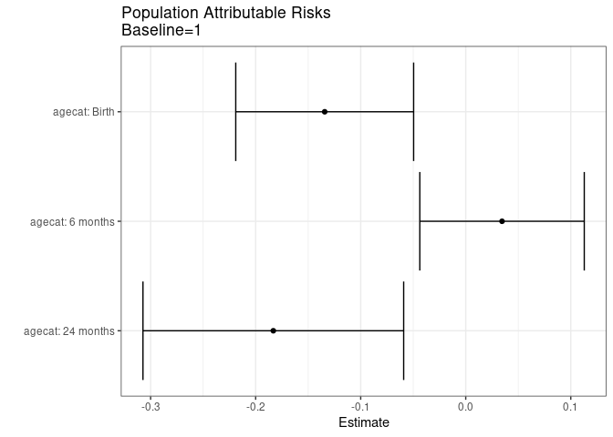

## Results Table

### Parameter: TSM

| agecat | intervention_level | baseline_level | estimate | ci_lower | ci_upper |
| --- | --- | --- | --- | --- | --- |
| Birth | 1 | NA | -0.6891335 | -0.7780677 | -0.6001993 |
| Birth | 2 | NA | -0.6561941 | -0.7417843 | -0.5706040 |
| Birth | 3 | NA | -0.7665946 | -0.8432271 | -0.6899622 |
| Birth | 4 | NA | -0.7697731 | -0.8505284 | -0.6890178 |
| Birth | 5 | NA | -0.8483352 | -0.9454676 | -0.7512029 |
| Birth | 6 | NA | -0.8812294 | -0.9707238 | -0.7917350 |
| Birth | 7 | NA | -0.9059219 | -0.9860219 | -0.8258219 |
| Birth | 8 | NA | -0.8935153 | -0.9688208 | -0.8182098 |
| Birth | 9 | NA | -0.8768806 | -0.9470892 | -0.8066721 |
| Birth | 10 | NA | -0.9236729 | -0.9890386 | -0.8583071 |
| Birth | 11 | NA | -0.8432826 | -0.9118377 | -0.7747276 |
| Birth | 12 | NA | -0.7853573 | -0.8511122 | -0.7196025 |
| 6 months | 1 | NA | -0.0704322 | -0.1523119 | 0.0114476 |
| 6 months | 2 | NA | -0.0897267 | -0.1608774 | -0.0185760 |
| 6 months | 3 | NA | -0.0920873 | -0.1602780 | -0.0238965 |
| 6 months | 4 | NA | -0.0421585 | -0.1100040 | 0.0256869 |
| 6 months | 5 | NA | 0.0075096 | -0.0626457 | 0.0776649 |
| 6 months | 6 | NA | -0.0236688 | -0.0968395 | 0.0495018 |
| 6 months | 7 | NA | 0.0306876 | -0.0307766 | 0.0921517 |
| 6 months | 8 | NA | -0.0384475 | -0.0995965 | 0.0227016 |
| 6 months | 9 | NA | -0.0161484 | -0.0775298 | 0.0452329 |
| 6 months | 10 | NA | -0.0275656 | -0.0850431 | 0.0299119 |
| 6 months | 11 | NA | -0.0722436 | -0.1347914 | -0.0096958 |
| 6 months | 12 | NA | -0.0045888 | -0.0685879 | 0.0594102 |
| 24 months | 1 | NA | -0.5815934 | -0.7102767 | -0.4529100 |
| 24 months | 2 | NA | -0.7334059 | -0.8263445 | -0.6404673 |
| 24 months | 3 | NA | -0.7960674 | -0.8874990 | -0.7046359 |
| 24 months | 4 | NA | -0.7698483 | -0.8716433 | -0.6680533 |
| 24 months | 5 | NA | -0.7830562 | -0.9082635 | -0.6578489 |
| 24 months | 6 | NA | -0.9462675 | -1.0539993 | -0.8385358 |
| 24 months | 7 | NA | -0.8471130 | -0.9413591 | -0.7528670 |
| 24 months | 8 | NA | -0.8731977 | -0.9665382 | -0.7798572 |
| 24 months | 9 | NA | -0.7981983 | -0.8940966 | -0.7023000 |
| 24 months | 10 | NA | -0.7179818 | -0.8266350 | -0.6093285 |
| 24 months | 11 | NA | -0.6963786 | -0.7957171 | -0.5970400 |
| 24 months | 12 | NA | -0.6057127 | -0.6938787 | -0.5175466 |

### Parameter: E(Y)

| agecat | intervention_level | baseline_level | estimate | ci_lower | ci_upper |
| --- | --- | --- | --- | --- | --- |
| Birth | NA | NA | -0.8234099 | -0.8456508 | -0.8011690 |
| 6 months | NA | NA | -0.0358863 | -0.0548330 | -0.0169396 |
| 24 months | NA | NA | -0.7647769 | -0.7942265 | -0.7353272 |

### Parameter: ATE

| agecat | intervention_level | baseline_level | estimate | ci_lower | ci_upper |
| --- | --- | --- | --- | --- | --- |
| Birth | 1 | 1 | 0.0000000 | 0.0000000 | 0.0000000 |
| Birth | 2 | 1 | 0.0329394 | -0.0906439 | 0.1565226 |
| Birth | 3 | 1 | -0.0774611 | -0.1949694 | 0.0400472 |
| Birth | 4 | 1 | -0.0806396 | -0.2009466 | 0.0396675 |
| Birth | 5 | 1 | -0.1592017 | -0.2910254 | -0.0273781 |
| Birth | 6 | 1 | -0.1920959 | -0.3183378 | -0.0658540 |
| Birth | 7 | 1 | -0.2167884 | -0.3364789 | -0.0970978 |
| Birth | 8 | 1 | -0.2043818 | -0.3209642 | -0.0877994 |
| Birth | 9 | 1 | -0.1877471 | -0.3011715 | -0.0743227 |
| Birth | 10 | 1 | -0.2345393 | -0.3449563 | -0.1241224 |
| Birth | 11 | 1 | -0.1541491 | -0.2664985 | -0.0417997 |
| Birth | 12 | 1 | -0.0962238 | -0.2069089 | 0.0144612 |
| 6 months | 1 | 1 | 0.0000000 | 0.0000000 | 0.0000000 |
| 6 months | 2 | 1 | -0.0192945 | -0.1279113 | 0.0893223 |
| 6 months | 3 | 1 | -0.0216551 | -0.1284887 | 0.0851785 |
| 6 months | 4 | 1 | 0.0282736 | -0.0781332 | 0.1346805 |
| 6 months | 5 | 1 | 0.0779418 | -0.0299950 | 0.1858786 |
| 6 months | 6 | 1 | 0.0467633 | -0.0630984 | 0.1566251 |
| 6 months | 7 | 1 | 0.1011197 | -0.0013328 | 0.2035723 |
| 6 months | 8 | 1 | 0.0319847 | -0.0702036 | 0.1341730 |
| 6 months | 9 | 1 | 0.0542837 | -0.0481399 | 0.1567073 |
| 6 months | 10 | 1 | 0.0428666 | -0.0572293 | 0.1429625 |
| 6 months | 11 | 1 | -0.0018114 | -0.1049583 | 0.1013355 |
| 6 months | 12 | 1 | 0.0658433 | -0.0381877 | 0.1698743 |
| 24 months | 1 | 1 | 0.0000000 | 0.0000000 | 0.0000000 |
| 24 months | 2 | 1 | -0.1518125 | -0.3103890 | 0.0067640 |
| 24 months | 3 | 1 | -0.2144741 | -0.3721153 | -0.0568329 |
| 24 months | 4 | 1 | -0.1882549 | -0.3526709 | -0.0238390 |
| 24 months | 5 | 1 | -0.2014628 | -0.3808971 | -0.0220286 |
| 24 months | 6 | 1 | -0.3646742 | -0.5325426 | -0.1968058 |
| 24 months | 7 | 1 | -0.2655197 | -0.4245682 | -0.1064712 |
| 24 months | 8 | 1 | -0.2916043 | -0.4509675 | -0.1322411 |
| 24 months | 9 | 1 | -0.2166049 | -0.3769849 | -0.0562249 |
| 24 months | 10 | 1 | -0.1363884 | -0.3048496 | 0.0320728 |
| 24 months | 11 | 1 | -0.1147852 | -0.2769384 | 0.0473680 |
| 24 months | 12 | 1 | -0.0241193 | -0.1798387 | 0.1316002 |

### Parameter: PAR

| agecat | intervention_level | baseline_level | estimate | ci_lower | ci_upper |
| --- | --- | --- | --- | --- | --- |
| Birth | 1 | NA | -0.1342764 | -0.2189461 | -0.0496067 |
| 6 months | 1 | NA | 0.0345459 | -0.0437371 | 0.1128289 |
| 24 months | 1 | NA | -0.1831835 | -0.3072760 | -0.0590910 |